# Between-Sample (Beta) Diversity of Microbes along a Salinity Gradient

# 3. Scale Read Counts

```r
min(sample_sums(archaeal_rooted_physeq))
```

```
## [1] 9539
```

```r
# Scale the reads
scaled_physeq <-
  archaeal_rooted_physeq %>%
  scale_reads(round = "exactround")

# Look at it
scaled_physeq
```

```
## phyloseq-class experiment-level object
## otu_table()   OTU Table:         [ 9286 taxa and 36 samples ]
## sample_data() Sample Data:       [ 36 samples by 9 sample variables ]
## tax_table()   Taxonomy Table:    [ 9286 taxa by 9 taxonomic ranks ]
## phy_tree()    Phylogenetic Tree: [ 9286 tips and 9285 internal nodes ]
```

```r
# Look at it more!
#View(data.frame(otu_table(archaeal_rooted_physeq)))
#View(data.frame(otu_table(scaled_physeq)))

# Confirm seq read depth of scaled_physeq
scaled_TotalSeqs_df <-
  scaled_physeq %>%
  sample_sums() %>%
  data.frame()

colnames(scaled_TotalSeqs_df)[1] <- "TotalSeqs"

# add a new column of num_ASVs (RAW, non-noramlized # ASVs)
scaled_TotalSeqsASVs_df <-
  scaled_TotalSeqs_df %>%
  mutate(num_ASVs = colSums(otu_table(scaled_physeq) > 1))

# Plot it!
scaledSeq_histogram <-
  scaled_TotalSeqs_df %>%
  ggplot(aes(x = TotalSeqs)) +
  geom_histogram(bins = 50) +
  labs(title = "Scaled Seq Depth Histogram") +
  scale_x_continuous(limits = c(0, 50000)) +
  theme_bw()

# Scaling always gives us a range!
# MInimum sequences
min(scaled_TotalSeqs_df$TotalSeqs)
```

```
## [1] 9539
```

```r
# Total Range
range(scaled_TotalSeqs_df)
```

```
## [1] 9539 9539
```

```r
# How many is that range?
range_seqs <- (max(scaled_TotalSeqs_df$TotalSeqs) - min(scaled_TotalSeqs_df$TotalSeqs))
range_seqs
```

```
## [1] 0
```

```r
# And in terms of percent?
range_seqs/max(scaled_TotalSeqs_df$TotalSeqs)
```

```
## [1] 0
```

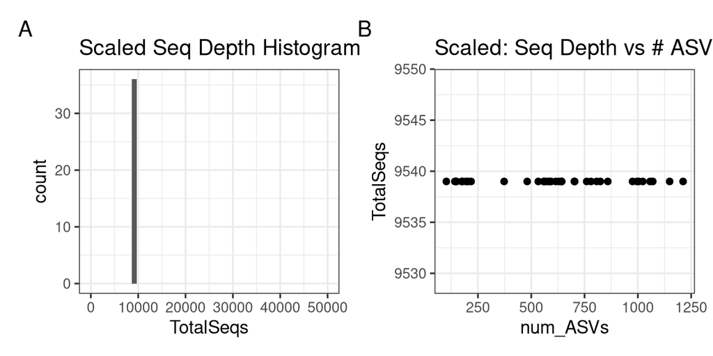

```r
#View(scaled_TotalSeqs_df)

# Set the axis min and max for the next plot
max_y <- max(scaled_TotalSeqs_df$TotalSeqs) + 10
min_y <- min(scaled_TotalSeqs_df$TotalSeqs) - 10

# Now, draw the plot
scaledSeq_vs_numASV_plot <-
  scaled_TotalSeqsASVs_df %>%
  ggplot(aes(x = num_ASVs, y = TotalSeqs)) +
  geom_point() +
  scale_y_continuous(limits = c(min_y, max_y)) +
  #geom_smooth(method = "lm") +
  theme_bw() +
  labs(title = "Scaled: Seq Depth vs # ASVs")

# Put the two plots together.
scaledSeq_histogram + scaledSeq_vs_numASV_plot +
  plot_annotation(tag_levels = "A")
```

INTERPRETATION #3: I scaled the read depth to 9539 sequences (the minimum sequencing depth). Using the exactcount rounding function, all my samples had 9539 as the final sequencing depth.

# 3. Calculating dissimilarity

Now, let’s make distance objects of each of the dissimiliarity measures above!

```r
# Sorensen Dissimiliarty
scaled_sorensen_dist <- phyloseq::distance(scaled_physeq, method = "bray", binary = TRUE)

# What does it look like?
class(scaled_sorensen_dist)
```

```
## [1] "dist"
```

```r
str(scaled_sorensen_dist)
```

```
##  'dist' num [1:630] 0.407 0.317 0.911 0.966 0.968 ...
##  - attr(*, "maxdist")= num 1
##  - attr(*, "Size")= int 36
##  - attr(*, "Labels")= chr [1:36] "SRR12183139" "SRR12183147" "SRR12183158" "SRR12183176" ...
##  - attr(*, "Diag")= logi FALSE
##  - attr(*, "Upper")= logi FALSE
##  - attr(*, "method")= chr "binary bray"
##  - attr(*, "call")= language vegdist(x = c(0, 6, 1, 0, 0, 0, 0, 2, 0, 0, 0, 0, 0, 0, 0, 0, 0, 0, 7,  0, 0, 0, 0, 0, 3, 0, 0, 0, 0, 2, 0, 0, 0,| __truncated__ ...
```

```r
#head(as.matrix(scaled_sorensen_dist))

# Bray-Curtis Dissimiliarty
scaled_bray_dist <- phyloseq::distance(scaled_physeq, method = "bray", binary = FALSE)

# Abundance-Unweighted UniFrac
scaled_uUnifrac_dist <- phyloseq::distance(scaled_physeq, method = "unifrac")

# Abundance-Weighted UniFrac
scaled_wUnifrac_dist <- phyloseq::distance(scaled_physeq, method = "wunifrac")
```

INTERPRETATION #4: Weighted Unifrac is most appropriate since we’re interested to see if the dominant species in each sample are evolutionarily distinct.

# 5a. PERMANOVA: Testing Means/Centroids

The goal of PERMANOVA is to ask: *Do the centroids (i.e., means) differ between groups?*

## Key Parameters in `adonis2()`

- `strata`: Use strata to restrict permutations within groups, which is critical for paired or repeated measures designs. This would be a column in the `metadata_df`.
  - example: `strata = metadata_df$Sample_Names`
- `by`: Specifies how model terms are tested. It can be:
  - `by = "terms"`: (default) tests each term sequentially. Therefore, it is sensitive to the order in which we put the varaibles into the model.
  - `by = "margin"`: tests each term while adjusting for others (like Type III sum of squares). Using `margin` ensures that each term is tested independently of the others—especially important when interactions are included or the design is unbalanced.
  - `by = "none"`: tests only the full model.
- `parallel`: Runs permutations using multiple CPU cores. This is helpful for large datasets or when using a large number of permutations.

### Summary Table of Useful `adonis2()` Parameters

| Parameter | Purpose | When to Use |
| --- | --- | --- |
| `permutations` | Number of permutations for p-value calculation | Always (use 9999+ for more stable results) |
| `strata` | Restrict permutations within groups | For paired samples, repeated measures, or blocks |
| `by` | Controls how model terms are tested | Use `"margin"` to test each variable while adjusting for others |
| `method` | Calculate distance matrix internally | Only if supplying a raw OTU/ASV table |
| `sqrt.dist` | Apply square-root transformation to distances | Rarely needed; used in specific workflows |
| `parallel` | Run permutations using multiple CPU cores | Speeds up large analyses with many permutations |

## Categorical & Continuous Variables in PERMANOVA

`adonis2()` can also be run on continuous variables — and it’s actually a powerful way to test whether variation in microbial community composition is associated with continuous environmental or biological gradients (*e.g.,* pH, temperature, nutrient concentration, latitude, host age, etc.). In `adonis2()`, continuous variables are treated as predictors in a linear model-like framework. The test evaluates whether changes in the continuous variable are significantly associated with shifts in microbial community composition (as measured by your distance matrix).

For now, we will focus on comparing the Sorensen and the Bray-Curtis. More on UniFrac soon!

### WUNIFRAC

```r
# Sorensen
## 1. Run with by = terms for R² values, sensitive to order of variables!
## ALWAYS check and confirm the order of your terms and how they interact with each other.

metadata_df <- read_csv("data/metadata_full.csv")
```

```
## ──────────────────────────────────────────────────────── Delimiter: "," chr
## (5): ...1, scientific_name, experiment_title, soil_type, names dbl (6):
## denoisedF, denoisedR, merged, nochim, num_ASVs, TC_percent lgl (1):
## Sample_or_Control
```

```r
wunifrac_soil_adonis_terms1 <- adonis2(scaled_wUnifrac_dist ~ soil_type, data = metadata_df, by = "terms")
wunifrac_soil_adonis_terms1
```

```
## Permutation test for adonis under reduced model
## Terms added sequentially (first to last)
## Permutation: free
## Number of permutations: 999
##
## adonis2(formula = scaled_wUnifrac_dist ~ soil_type, data = metadata_df, by = "terms")
##           Df SumOfSqs      R2      F Pr(>F)
## soil_type  3  0.09788 0.28504 4.2526  0.001 ***
## Residual  32  0.24551 0.71496
## Total     35  0.34340 1.00000
## ---
## Signif. codes:  0 '***' 0.001 '**' 0.01 '*' 0.05 '.' 0.1 ' ' 1
```

```r
sorensen_soil_adonis_terms1 <- adonis2(scaled_sorensen_dist ~ soil_type, data = metadata_df, by = "terms")
sorensen_soil_adonis_terms1
```

```
## Permutation test for adonis under reduced model
## Terms added sequentially (first to last)
## Permutation: free
## Number of permutations: 999
##
## adonis2(formula = scaled_sorensen_dist ~ soil_type, data = metadata_df, by = "terms")
##           Df SumOfSqs      R2      F Pr(>F)
## soil_type  3   6.8221 0.52191 11.644  0.001 ***
## Residual  32   6.2494 0.47809
## Total     35  13.0715 1.00000
## ---
## Signif. codes:  0 '***' 0.001 '**' 0.01 '*' 0.05 '.' 0.1 ' ' 1
```

```r
bray_soil_adonis_terms1 <- adonis2(scaled_bray_dist ~ soil_type, data = metadata_df, by = "terms")
bray_soil_adonis_terms1
```

```
## Permutation test for adonis under reduced model
## Terms added sequentially (first to last)
## Permutation: free
## Number of permutations: 999
##
## adonis2(formula = scaled_bray_dist ~ soil_type, data = metadata_df, by = "terms")
##           Df SumOfSqs      R2      F Pr(>F)
## soil_type  3   5.2932 0.39446 6.9484  0.001 ***
## Residual  32   8.1256 0.60554
## Total     35  13.4188 1.00000
## ---
## Signif. codes:  0 '***' 0.001 '**' 0.01 '*' 0.05 '.' 0.1 ' ' 1
```

```r
unifrac_soil_adonis_terms1 <- adonis2(scaled_uUnifrac_dist ~ soil_type, data = metadata_df, by = "terms")
unifrac_soil_adonis_terms1
```

```
## Permutation test for adonis under reduced model
## Terms added sequentially (first to last)
## Permutation: free
## Number of permutations: 999
##
## adonis2(formula = scaled_uUnifrac_dist ~ soil_type, data = metadata_df, by = "terms")
##           Df SumOfSqs     R2      F Pr(>F)
## soil_type  3   4.2712 0.5048 10.873  0.001 ***
## Residual  32   4.1900 0.4952
## Total     35   8.4611 1.0000
## ---
## Signif. codes:  0 '***' 0.001 '**' 0.01 '*' 0.05 '.' 0.1 ' ' 1
```

### Understanding PERMANOVA output:

- **Pr(>F) Interpretation:** The p-value. Is it “*significant*”?
  - This represents the “*probability of observing an F-statistic this extreme (or more extreme), assuming the null hypothesis is true.*” In essence, this is the **p-value** from the permutation test. This value tells us whether the variance explained by a variable (or interaction) is significantly greater than expected by chance.
- **R<sup>2</sup> value Interpretation:** How much variation is explained by this variable—an effect size.
  - Not dependent on sample size.
  - Interpretable across studies!
  - R<sup>2</sup> (also called “pseudo R<sup>2</sup>” in PERMANOVA) is the proportion of total variation in the multivariate data that is explained by a specific variable or interaction.
    - R<sup>2</sup> = 0.25 means that the term explains 25% of the variation in the community composition.
    - R<sup>2</sup> = 0.03 means that the term explains only 3% of variation — possibly statistically significant but a small effect. This is important because 3% is not much variation! So, therefore, even it if is *significant* based on the p-value, it explains an *insignificant* amount of variation.
- **F-statistic Interpretation:** How strongly a variable separates groups, relative to residuals.
  - Higher F-values tell us that there is stronger separation of groups. he F-statistic is a ratio of explained to unexplained variation, adjusted for degrees of freedom — similar to traditional ANOVA, but applied to a distance matrix (like Bray-Curtis, Jaccard, *etc.*). It tells you how much more variation is explained by the model (with your term included) compared to the residual (unexplained) variation.

# 5b. Betadisper: Testing Variances/Dispersions

First, `betadisper()` will perform the following steps:

1. Input: A distance matrix (e.g., from vegdist() or phyloseq::distance()) and a grouping factor (e.g., station).
2. Calculate the centroid of each group in multivariate space (via PCoA).
3. Compute the distance from each sample to its group’s centroid.
4. Store those distances — these are the within-group dispersions.

Second, `permutest()` will perform the following steps:

1. Null hypothesis (H<sub>0</sub>): All groups have equal multivariate dispersion.
2. Observed F-statistic is calculated from the variation among group dispersions.
3. Permutations: Group labels are shuffled many times (*e.g.,* 999 times).
4. For each permutation, a new F-statistic is calculated.
5. The p-value is the proportion of permutations where the F is as extreme or more extreme than the observed F.

The result from `permutest()` is a robust non-parametric p-value testing whether dispersion differs across groups.

**Always run `betadisper()` and `permutest()` after PERMANOVA** to test whether the groups have similar within-group variation.

- If p > 0.05 (not significant), the PERMANOVA result is reliable.
- If p < 0.05 (significant), be cautious—group differences may be due to dispersion, not composition! However, not all is lost as we may expect this to be biologically true.

**In Summary:**

| Function | What it does | Significance test? | Output includes |
| --- | --- | --- | --- |
| `betadisper()` | Computes within-group distances to centroids (dispersion) | ❌ No | Distances, centroids, model object |
| `permutest()` | Tests if group dispersions differ using permutations | ✅ Yes | F-value, permutation-based p-value |

## Sorensen

```r
# Homogeneity of Disperson test with beta dispr
# Sorensen Betadisper - Soil
dispr_sorensen_station <- betadisper(scaled_sorensen_dist, metadata_df$soil_type)
# permutest() performs a non-parametric permutation test, which is robust and valid for the kind of data used in beta diversity analysis (e.g., dissimilarity matrices).
permutest(dispr_sorensen_station)
```

```
##
## Permutation test for homogeneity of multivariate dispersions
## Permutation: free
## Number of permutations: 999
##
## Response: Distances
##           Df  Sum Sq  Mean Sq      F N.Perm Pr(>F)
## Groups     3 0.18916 0.063053 15.679    999  0.001 ***
## Residuals 32 0.12869 0.004022
## ---
## Signif. codes:  0 '***' 0.001 '**' 0.01 '*' 0.05 '.' 0.1 ' ' 1
```

```r
dispr_bray_station <- betadisper(scaled_bray_dist, metadata_df$soil_type)
permutest(dispr_bray_station)
```

```
##
## Permutation test for homogeneity of multivariate dispersions
## Permutation: free
## Number of permutations: 999
##
## Response: Distances
##           Df   Sum Sq   Mean Sq      F N.Perm Pr(>F)
## Groups     3 0.003458 0.0011525 0.3751    999  0.763
## Residuals 32 0.098318 0.0030724
```

```r
dispr_unifrac_station <- betadisper(scaled_uUnifrac_dist, metadata_df$soil_type)
permutest(dispr_unifrac_station)
```

```
##
## Permutation test for homogeneity of multivariate dispersions
## Permutation: free
## Number of permutations: 999
##
## Response: Distances
##           Df   Sum Sq   Mean Sq      F N.Perm Pr(>F)
## Groups     3 0.071225 0.0237418 9.5737    999  0.001 ***
## Residuals 32 0.079356 0.0024799
## ---
## Signif. codes:  0 '***' 0.001 '**' 0.01 '*' 0.05 '.' 0.1 ' ' 1
```

```r
dispr_wunifrac_station <- betadisper(scaled_wUnifrac_dist, metadata_df$soil_type)
permutest(dispr_wunifrac_station)
```

```
##
## Permutation test for homogeneity of multivariate dispersions
## Permutation: free
## Number of permutations: 999
##
## Response: Distances
##           Df    Sum Sq    Mean Sq     F N.Perm Pr(>F)
## Groups     3 0.0010074 0.00033578 0.701    999  0.549
## Residuals 32 0.0153289 0.00047903
```

**Next steps:**

- Use ordination plots to visually assess whether centroids are distinct or just differently dispersed (*We are about to do this!*)
- Plot distances to group centroids
- Consider running PERMANOVA on a subset with equal dispersions
- Reflect on ecological plausibility — are the dispersion differences biologically meaningful? Sometimes real biological processes cause both composition shifts and dispersion changes (e.g., disturbance, environmental heterogeneity)! So, don’t lose your heart about your data yet! :)

> Even with unequal dispersion, true ecological differences can still exist — the key is to **interpret with care** and use supporting evidence.

If this happens, the results could be written something like: “*PERMANOVA indicated significant differences in microbial community composition across treatments (p < 0.001), though betadisper was also significant (p = 0.03), suggesting differences in within-group dispersion. Ordination plots showed distinct clustering of treatment centroids, supporting genuine compositional differences, though interpretations must consider potential heterogeneity in dispersion.*”

INTERPRETATION #6: Although unweighted unifrac and sorensen have the higher R2 and F values, they also have significant differences in dispersion. Weighted unifrac and bray curtis, however, do not have significantly different dispersions among groups. Therefore, we can more cleanly interpret the centroid of these dissimilarity measures as significantly different.

INTERPRETATION #7: Taking into account both the betadisper()/permutest() and the PERMANOVA (adonis2()) test that you ran, we can conclude that dominant species (both when taking into account phylogeny or not) have significantly different centroids, while richness measures may have different centroids, but ordination plots are needed to verify.

# 6. Visualize Community Dissimilarity with Ordination

## Key Types of Ordination Methods

In practice, the most common ordination methods in microbial ecology are:

1. **PCoA** - Eigen-based analysis, linear, axis coefficients are meaningful because they represent the eigenvectors.
2. **NMDS** - Non-linear method, axes are not meaningful, smush many axes of data into 2 axes

# 6a. PCoA: Principal Coordinates Analysis

```r
### SORENSEN
# First, calculate PCoA with Sorensen
scaled_soren_pcoa <-
  ordinate(physeq = scaled_physeq,
         method = "PCoA",
         distance = "bray", binary = TRUE)

# Take a quick look
str(scaled_soren_pcoa)
```

```
## List of 5
##  $ correction: chr [1:2] "none" "1"
##  $ note      : chr "There were no negative eigenvalues. No correction was applied"
##  $ values    :'data.frame':  35 obs. of  5 variables:
##   ..$ Eigenvalues   : num [1:35] 3.313 1.995 1.559 0.85 0.424 ...
##   ..$ Relative_eig  : num [1:35] 0.2535 0.1526 0.1193 0.065 0.0324 ...
##   ..$ Broken_stick  : num [1:35] 0.1185 0.0899 0.0756 0.0661 0.059 ...
##   ..$ Cumul_eig     : num [1:35] 0.253 0.406 0.525 0.59 0.623 ...
##   ..$ Cumul_br_stick: num [1:35] 0.118 0.208 0.284 0.35 0.409 ...
##  $ vectors   : num [1:36, 1:35] -0.5156 -0.5109 -0.5082 0.0121 0.245 ...
##   ..- attr(*, "dimnames")=List of 2
##   .. ..$ : chr [1:36] "SRR12183139" "SRR12183147" "SRR12183158" "SRR12183176" ...
##   .. ..$ : chr [1:35] "Axis.1" "Axis.2" "Axis.3" "Axis.4" ...
##  $ trace     : num 13.1
##  - attr(*, "class")= chr "pcoa"
```

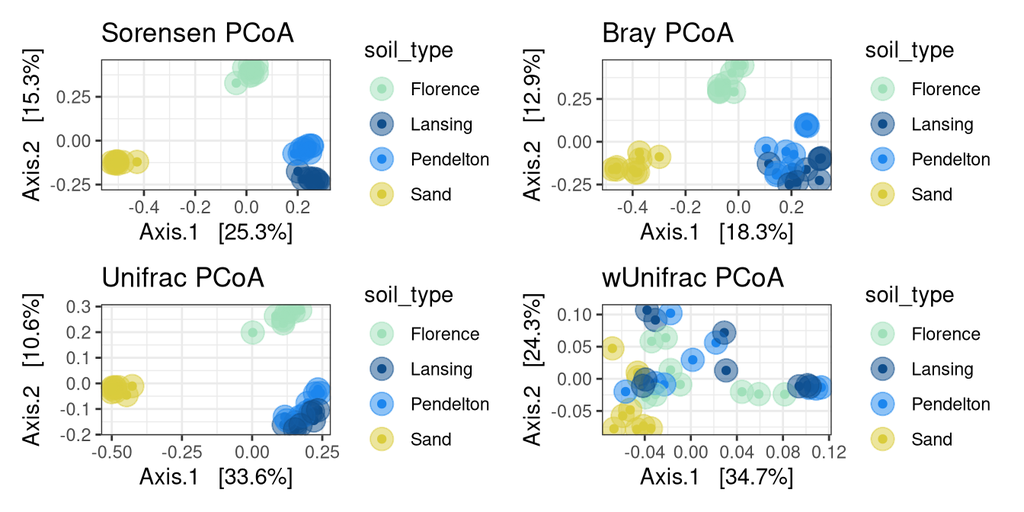

```r
# Plot it: Sorensen PCoA
sorensen_pcoa_plot <-
  plot_ordination(physeq = scaled_physeq,
                ordination = scaled_soren_pcoa,
                color = "soil_type",
                title = "Sorensen PCoA") +
  scale_color_manual(values = soil_colors) +
  scale_shape_manual(values = c(15, 16, 17)) +
  geom_point(size = 5, alpha = 0.5, aes(color = soil_type)) +
  theme_bw() +
  theme(legend.position = "right")

# bray
scaled_bray_pcoa <-
  ordinate(physeq = scaled_physeq,
         method = "PCoA",
         distance = "bray")

bray_pcoa_plot <-
  plot_ordination(physeq = scaled_physeq,
                ordination = scaled_bray_pcoa,
                color = "soil_type",
                title = "Bray PCoA") +
  scale_color_manual(values = soil_colors) +
  scale_shape_manual(values = c(15, 16, 17)) +
  geom_point(size = 5, alpha = 0.5, aes(color = soil_type)) +
  theme_bw() +
  theme(legend.position = "right")

# unifrac
scaled_unifrac_pcoa <-
  ordinate(physeq = scaled_physeq,
         method = "PCoA",
         distance = "unifrac")

unifrac_pcoa_plot <-
  plot_ordination(physeq = scaled_physeq,
                ordination = scaled_unifrac_pcoa,
                color = "soil_type",
                title = "Unifrac PCoA") +
  scale_color_manual(values = soil_colors) +
  scale_shape_manual(values = c(15, 16, 17)) +
  geom_point(size = 5, alpha = 0.5, aes(color = soil_type)) +
  theme_bw() +
  theme(legend.position = "right")

# wunifrac
scaled_wunifrac_pcoa <-
  ordinate(physeq = scaled_physeq,
         method = "PCoA",
         distance = "wunifrac")

wunifrac_pcoa_plot <-
  plot_ordination(physeq = scaled_physeq,
                ordination = scaled_wunifrac_pcoa,
                color = "soil_type",
                title = "wUnifrac PCoA") +
  scale_color_manual(values = soil_colors) +
  scale_shape_manual(values = c(15, 16, 17)) +
  geom_point(size = 5, alpha = 0.5, aes(color = soil_type)) +
  theme_bw() +
  theme(legend.position = "right")

# Show the plots
sorensen_pcoa_plot + bray_pcoa_plot + unifrac_pcoa_plot + wunifrac_pcoa_plot
```

INTERPRETATION #8: Strangely, while the betadispr()/permutest() reported significantly different dispersions for Sorensen and unweighted unifrac, they seem to be actually more distinct and organized as clusters than weighted unifrac and Bray-Curtis. I think it is reasonable to say that the centroids are different for richness measures.

## 6b. NMDS: Non-Metric Multidimensional Scaling

*Okay, let’s draw some NMDS plots!*

```r
### SORENSEN
# First, calculate PCoA with Sorensen
scaled_soren_nmds <-
  ordinate(physeq = scaled_physeq,
         method = "NMDS",
         distance = "bray", binary = TRUE)
```

```
## Square root transformation
## Wisconsin double standardization
## *** Best solution repeated 1 times
```

```r
# Take a quick look
str(scaled_soren_nmds)
```

[output not shown]

```r
# Plot it: Sorensen PCoA
sorensen_nmds_plot <-
  plot_ordination(physeq = scaled_physeq,
                ordination = scaled_soren_nmds,
                color = "soil_type",
                title = "Sorensen NMDS") +
  scale_color_manual(values = soil_colors) +
  scale_shape_manual(values = c(15, 16, 17)) +
  geom_point(size = 5, alpha = 0.5, aes(color = soil_type)) +
  theme_bw() +
  theme(legend.position = "right")

# bray
scaled_bray_nmds <-
  ordinate(physeq = scaled_physeq,
         method = "NMDS",
         distance = "bray")
```

```
## Square root transformation
## Wisconsin double standardization
## *** Best solution repeated 2 times
```

```r
bray_nmds_plot <-
  plot_ordination(physeq = scaled_physeq,
                ordination = scaled_bray_nmds,
                color = "soil_type",
                title = "Bray NMDS") +
  scale_color_manual(values = soil_colors) +
  scale_shape_manual(values = c(15, 16, 17)) +
  geom_point(size = 5, alpha = 0.5, aes(color = soil_type)) +
  theme_bw() +
  theme(legend.position = "right")

# unifrac
scaled_unifrac_nmds <-
  ordinate(physeq = scaled_physeq,
         method = "NMDS",
         distance = "unifrac")
```

```
## *** Best solution repeated 3 times
```

```r
unifrac_nmds_plot <-
  plot_ordination(physeq = scaled_physeq,
                ordination = scaled_unifrac_nmds,
                color = "soil_type",
                title = "Unifrac NMDS") +
  scale_color_manual(values = soil_colors) +
  scale_shape_manual(values = c(15, 16, 17)) +
  geom_point(size = 5, alpha = 0.5, aes(color = soil_type)) +
  theme_bw() +
  theme(legend.position = "right")

# wunifrac
scaled_wunifrac_nmds <-
  ordinate(physeq = scaled_physeq,
         method = "NMDS",
         distance = "wunifrac")
```

```
## *** Best solution repeated 12 times
```

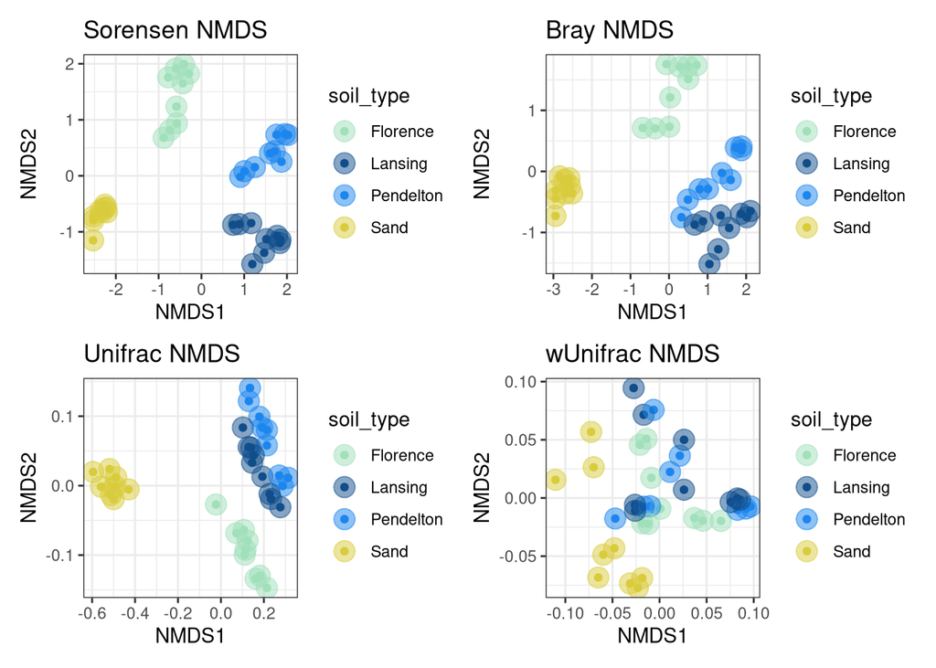

```r
wunifrac_nmds_plot <-
  plot_ordination(physeq = scaled_physeq,
                ordination = scaled_wunifrac_nmds,
                color = "soil_type",
                title = "wUnifrac NMDS") +
  scale_color_manual(values = soil_colors) +
  scale_shape_manual(values = c(15, 16, 17)) +
  geom_point(size = 5, alpha = 0.5, aes(color = soil_type)) +
  theme_bw() +
  theme(legend.position = "right")

# Show the plots
sorensen_nmds_plot + bray_nmds_plot + unifrac_nmds_plot + wunifrac_nmds_plot
```

INTERPRETATION #9: Rather than clusters, some of the data in an NMDS form a line (e.g. pendelton, lansing, florence in unifrac, sorensen, and bray). Sand seems to be pretty clustered. Between sorensen and bray, there doesn’t seem to be much of a difference, whereas there is a significant difference in the uniformity and cluster distinctiveness between unifrac and wunifrac.

## All ordinations together!

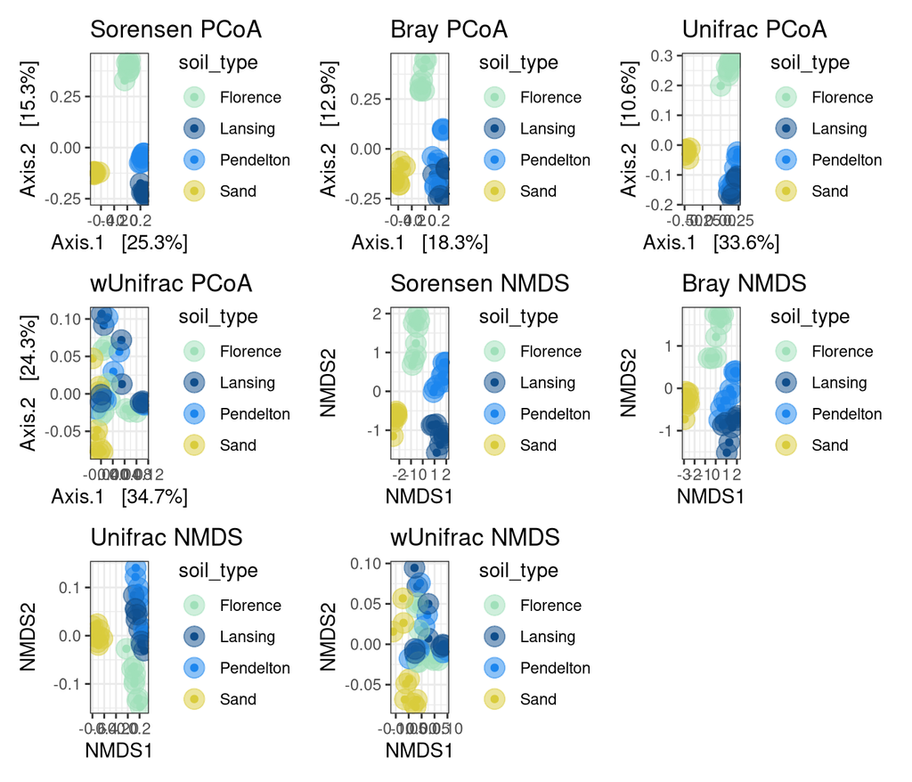

```r
sorensen_pcoa_plot + bray_pcoa_plot + unifrac_pcoa_plot + wunifrac_pcoa_plot + sorensen_nmds_plot + bray_nmds_plot + unifrac_nmds_plot + wunifrac_nmds_plot
```

INTERPRETATION #10: I think PCoA better shows the separation of centroids for sorensen and unifrac. Since these were the methods with significant dispersions, the purpose of the plots are mainly to show that it is not only the dispersions that are significant but also the location effect. This is more pronounced in the PCoA in my opinion.

# Final info for Reproducibility